# Universidad autonoma del estado de Mexico

## Juan Octavio Gonzalez Jimenez

### Graficacion Computacional

```python
import numpy as np
import matplotlib.pyplot as plt
```

### Visualización de un vector con quiver (flechas) en coordenadas 2D

plt.quiver(1, 2, 3, 4, scale_units='xy', angles='xy', scale=1)

### Dibuja un vector que comienza en (1, 2) y se extiende (3, 4) unidades.

### Ajustes de límites para los ejes x e y

plt.xlim(0, 4) # Establece el límite del eje x entre 0 y 4 plt.ylim(0, 8) # Establece el límite del eje y entre 0 y 8

### Agrega guías (líneas verticales y horizontales) para el vector

plt.axvline(x=1) # Línea vertical en x = 1 (inicio del vector)  
plt.axhline(y=2) # Línea horizontal en y = 2 (inicio del vector)  
plt.axvline(x=1+3) # Línea vertical en x = 4 (extremo del vector)  
plt.axhline(y=2+4) # Línea horizontal en y = 6 (extremo del vector)

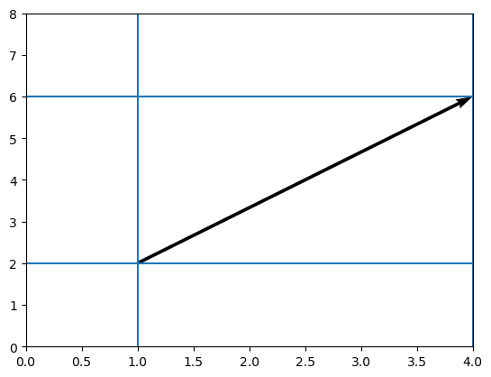

```python
plt.quiver(1,2, 3,4, scale_units='xy', angles='xy', scale=1)
plt.xlim(0,4)
plt.ylim(0,8)

plt.axvline(x=1)
plt.axhline(y=2)

plt.axvline(x=1+3)
plt.axhline(y=2+4)
```

### Agrega otros vectores con coordenadas de origen y destino

plt.quiver([0, 0], [0, 0], [1, 2], [4, 2], scale_units='xy', angles='xy', scale=1)

### Dibuja dos vectores: el primero de (0,0) a (1,4) y el segundo de (0,0) a (2,2).

plt.xlim(0, 4)  
plt.ylim(0, 4)

```
(0.0, 4.0)
```

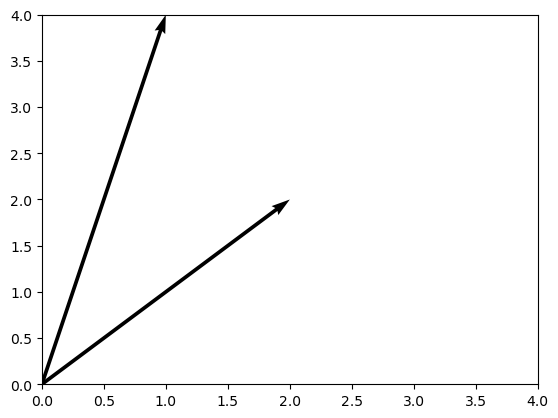

```python
plt.quiver([0, 0], [0, 0], [1, 2], [4, 2], scale_units='xy', angles='xy', scale=1)

plt.xlim(0, 4)
plt.ylim(0, 4)
```

plt.quiver([1, 0], [2, 0], [1, 2], [3, 2], scale_units='xy', angles='xy', scale=1)

### Dibuja dos vectores: el primero desde (1,2) y el segundo desde (0,0).

plt.xlim(0, 4) plt.ylim(0, 6)

### Líneas de referencia con estilo gris punteado para resaltar el inicio de los vectores

plt.axvline(x=1, color='gray', linestyle='--', alpha=0.3) # Línea gris en x=1  
plt.axhline(y=2, color='gray', linestyle='--', alpha=0.3) # Línea gris en y=2

plt.axvline(x=2, color='gray', linestyle='--', alpha=0.3) # Línea gris en x=2  
plt.axhline(y=2, color='gray', linestyle='--', alpha=0.3) # Línea gris en y=2

plt.axvline(x=2, color='gray', linestyle='--', alpha=0.3) # Línea gris en x=2  
plt.axhline(y=5, color='gray', linestyle='--', alpha=0.3) # Línea gris en y=5

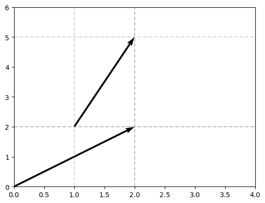

```python
plt.quiver([1, 0], [2, 0], [1, 2], [3, 2], scale_units='xy', angles='xy', scale=1)
# Dibuja dos vectores: el primero desde (1,2) y el segundo desde (0,0).
plt.xlim(0, 4)
plt.ylim(0, 6)

plt.axvline(x=1, color='gray', linestyle='--', alpha=0.3)
plt.axhline(y=2, color='gray', linestyle='--', alpha=0.3)

plt.axvline(x=2, color='gray', linestyle='--', alpha=0.3)
plt.axhline(y=2, color='gray', linestyle='--', alpha=0.3)

plt.axvline(x=2, color='gray', linestyle='--', alpha=0.3)
plt.axhline(y=5, color='gray', linestyle='--', alpha=0.3)
```

### Creación de vectores utilizando numpy

v1 = np.array([1, 2]) # Vector 1 con componentes (1,2) v2 = np.array([3, 4]) # Vector 2 con componentes (3,4)

### Dibuja los dos vectores anteriores con quiver

plt.quiver([0, 0], [0, 0], [v1[0], v2[0]], [v1[1], v2[1]], angles='xy', scale_units='xy', scale=1) plt.xlim(0, max(v1[0], v2[0])) # Ajusta el límite del eje x con base en los vectores plt.ylim(0, max(v1[1], v2[1])) # Ajusta el límite del eje y con base en los vectores

### Más líneas de referencia para resaltar el inicio y fin de los vectores

plt.axvline(x=1, alpha=0.2, linestyle='--') # Línea punteada en x=1 plt.axhline(y=2, alpha=0.2, linestyle='--') # Línea punteada en y=2 plt.axvline(x=3, alpha=0.2, linestyle='--') # Línea punteada en x=3 plt.axhline(y=4, alpha=0.2, linestyle='--') # Línea punteada en y=4

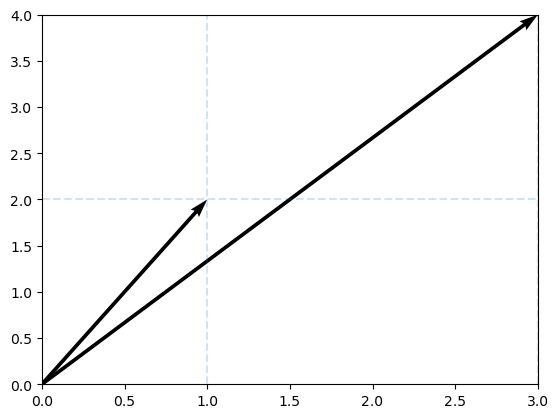

```python
v1 = np.array([1, 2])
v2 = np.array([3, 4])


plt.quiver([0, 0], [0, 0], [v1[0], v2[0]], [v1[1], v2[1]], angles='xy', scale_units='xy', scale=1)
plt.xlim(0, max(v1[0], v2[0]))
plt.ylim(0, max(v1[1], v2[1]))


plt.axvline(x=1, alpha=0.2, linestyle='--')
plt.axhline(y=2, alpha=0.2, linestyle='--')
plt.axvline(x=3, alpha=0.2, linestyle='--')
plt.axhline(y=4, alpha=0.2, linestyle='--')
```

```
Función que grafica múltiples vectores en un gráfico 2D.

Parámetros:
- vecs: Lista de vectores (como arrays de numpy) a graficar.
- cols: Lista de colores para cada vector.

plt.figure(figsize=(5,5))  # Establece el tamaño de la figura
for i in range(len(vecs)):  # Itera sobre los vectores
    vec = vecs[i]
    plt.quiver(0, 0, vec[0], vec[1], color=cols[i], angles='xy', scale_units='xy', scale=1)
    # Dibuja cada vector desde el origen (0,0) con el color correspondiente.
```

### Creación de tres vectores

v1 = np.array([1, 2]) # Primer vector (1,2) v2 = np.array([3, 4]) # Segundo vector (3,4) v3 = np.array([8, 4]) # Tercer vector (8,4)

### Llamada a la función grafvecs para graficar los tres vectores

grafvecs([v1, v2, v3], ['blue', 'red', 'black']) # Asigna colores: azul, rojo y negro plt.xlim(0, max(v1[0], v2[0], v3[0])) # Ajusta el límite del eje x plt.ylim(0, max(v1[1], v2[1], v3[1])) # Ajusta el límite del eje y

```
(0.0, 4.0)
```

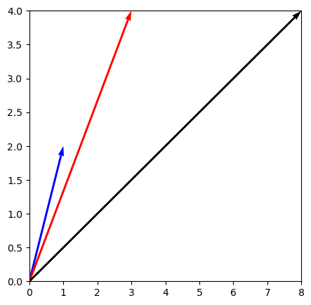

```python
def grafvecs(vecs, cols):
    plt.figure(figsize=(5,5))
    for i in range(len(vecs)):
        vec = vecs[i]
        plt.quiver(0, 0, vec[0], vec[1], color=cols[i], angles='xy', scale_units='xy', scale=1)



v1 = np.array([1, 2])
v2 = np.array([3, 4])
v3 = np.array([8, 4])


grafvecs([v1, v2, v3], ['blue', 'red', 'black'])
plt.xlim(0, max(v1[0], v2[0], v3[0]))
plt.ylim(0, max(v1[1], v2[1], v3[1]))
```